clc;clear;

workingpath='/Volumes/WD_D/gufei/monkey_data/campwater';

cd(workingpath);

files=dir('*side.csv');

alldata=cell(1,length(files));

% middle point

m=zeros(1,length(files));

conditions=cell(1,length(files));

for f=1:length(files)

% load data

filename=files(f).name;

% replace _ with -

conditions{f}=strrep(filename(1:end-9),'_','-');

% 从第二行第一列读取数据

data=csvread(filename,1,0);

m(f)=mean([min(data(:,2)) max(data(:,2))]);

disp(filename)

disp([min(data(:,2)) mean([min(data(:,2)) max(data(:,2))]) max(data(:,2)) min(data(:,3)) mean([min(data(:,3)) max(data(:,3))]) max(data(:,3))])

% y is reversed

data(:,3)=140-data(:,3);

% 绘制轨迹

% monkeyt(data(:,2),data(:,3),0.1,0.001);

% 查看分布情况

% length(data(data(:,2)>100,3));

% length(data(data(:,2)<=100,3));

%

% length(data(data(:,2)<=90,3));

% length(data(data(:,2)>=110,3));

%

% length(data(data(:,2)<=80,3));

% length(data(data(:,2)>=120,3));

% max(data(:,2));

% min(data(:,2));

% mean([max(data(:,2)),min(data(:,2))]);

%保存到cell中

alldata{f}=data;

end

吲哚_L_20201001_side.csv

23.1664 122.3482 221.5300 60.9055 96.1718 131.4380

吲哚_R_20200930_side.csv

21.9848 121.9749 221.9650 70.9609 100.5874 130.2140

异戊酸_L_20200929_side.csv

19.6015 117.5563 215.5110 66.9861 97.6945 128.4030

异戊酸_R_20200926_side.csv

23.3736 122.8108 222.2480 67.8863 99.7327 131.5790

白桃_L_20201003_side.csv

19.3473 113.9021 208.4570 71.3002 100.3326 129.3650

白桃_R_20201004_side.csv

18.9209 112.4839 206.0470 72.9749 100.4169 127.8590

香蕉_L_20201008_side.csv

56.0087 110.5508 165.0930 80.2424 95.7127 111.1830

香蕉_R_20201009_side.csv

20.6690 123.1115 225.5540 57.2239 94.2035 131.1830

## Scale

for f=1:length(files)

data=alldata{f};

mid=m(f);

minvalue=min(data(:,2));

maxvalue=max(data(:,2));

data(data(:,2)<=mid,2)=(data(data(:,2)<=mid,2)-minvalue)*100/(mid-minvalue);

data(data(:,2)>mid,2)=100+(data(data(:,2)>mid,2)-mid)*100/(maxvalue-mid);

alldata{f}=data;

end

## 绘制轨迹

% for f=1:length(files)

% data=alldata{f};

% figure;

% % 绘制轨迹

% % monkeyt(data(:,2),data(:,3),0.1,0.001);

% monkeyt(data(:,2),data(:,3),0,0);

% title(conditions{f});

% end

## 整体的直方图

interval=5;

for f=1:length(files)

data=alldata{f};

% chisq test

disp(conditions{f})

for i=0:10:20

cutl=100-i;

cutr=100+i;

disp([cutl cutr])

% chit-chisquare test

[pvalue,st]=chit(data,cutl,cutr)

end

figure;

% x方向的分布

subplot(1,2,1)

hist(data(:,2),interval/2:interval:200-interval/2);

line([100 100],get(gca,'Ylim'),'linestyle',':')

title('x')

% y方向的分布

subplot(1,2,2)

hist(data(:,3));

title('y')

suptitle(conditions{f});

end

吲哚-L-20201001

100 100

pvalue = 0

st =

chi2stat: 2.6316e+04  
df: 1  
edges: [0 100 200]  
O: [70001 21051]  
E: [45526 45526]

90 110

pvalue = 0

st =

chi2stat: 2.7371e+04  
df: 1  
edges: [0 100 200]  
O: [69326 19906]  
E: [44616 44616]

80 120

pvalue = 0

st =

chi2stat: 3.0080e+04  
df: 1  
edges: [0 100 200]  
O: [68785 17762]  
E: [4.3274e+04 4.3274e+04]

吲哚-R-20200930

100 100

pvalue = 0

st =

chi2stat: 1.0479e+04  
df: 1  
edges: [0 100 200]  
O: [61363 30360]  
E: [4.5862e+04 4.5862e+04]

90 110

pvalue = 0

st =

chi2stat: 1.0758e+04  
df: 1  
edges: [0 100 200]  
O: [60759 29584]  
E: [4.5172e+04 4.5172e+04]

80 120

pvalue = 0

st =

chi2stat: 1.1667e+04  
df: 1  
edges: [0 100 200]  
O: [60110 28040]  
E: [44075 44075]

异戊酸-L-20200929

100 100

pvalue = 0

st =

chi2stat: 1.5679e+04  
df: 1  
edges: [0 100 200]  
O: [63861 26269]  
E: [45065 45065]

90 110

pvalue = 0

st =

chi2stat: 1.5793e+04  
df: 1  
edges: [0 100 200]  
O: [63404 25858]  
E: [44631 44631]

80 120

pvalue = 0

st =

chi2stat: 1.8163e+04  
df: 1  
edges: [0 100 200]  
O: [62956 23361]  
E: [4.3158e+04 4.3158e+04]

异戊酸-R-20200926

100 100

pvalue = 0

st =

chi2stat: 7.3309e+03  
df: 1  
edges: [0 100 200]  
O: [62716 35837]  
E: [4.9276e+04 4.9276e+04]

90 110

pvalue = 0

st =

chi2stat: 7.5099e+03  
df: 1  
edges: [0 100 200]  
O: [62208 35166]  
E: [48687 48687]

80 120

pvalue = 0

st =

chi2stat: 9.1177e+03  
df: 1  
edges: [0 100 200]  
O: [61365 32163]  
E: [46764 46764]

白桃-L-20201003

100 100

pvalue = 0

st =

chi2stat: 1.7864e+04  
df: 1  
edges: [0 100 200]  
O: [66455 25848]  
E: [4.6152e+04 4.6152e+04]

90 110

pvalue = 0

st =

chi2stat: 1.7004e+04  
df: 1  
edges: [0 100 200]  
O: [63794 24948]  
E: [44371 44371]

80 120

pvalue = 0

st =

chi2stat: 1.8063e+04  
df: 1  
edges: [0 100 200]  
O: [62077 22899]  
E: [42488 42488]

白桃-R-20201004

100 100

pvalue = 0

st =

chi2stat: 1.9502e+04  
df: 1  
edges: [0 100 200]  
O: [72541 28214]  
E: [5.0378e+04 5.0378e+04]

90 110

pvalue = 0

st =

chi2stat: 2.0618e+04  
df: 1  
edges: [0 100 200]  
O: [71846 26757]  
E: [4.9302e+04 4.9302e+04]

80 120

pvalue = 0

st =

chi2stat: 2.2556e+04  
df: 1  
edges: [0 100 200]  
O: [70754 24421]  
E: [4.7588e+04 4.7588e+04]

香蕉-L-20201008

100 100

pvalue = 0

st =

chi2stat: 2.3499e+04  
df: 1  
edges: [0 100 200]  
O: [69537 22924]  
E: [4.6230e+04 4.6230e+04]

90 110

pvalue = 0

st =

chi2stat: 2.4003e+04  
df: 1  
edges: [0 100 200]  
O: [68543 21940]  
E: [4.5242e+04 4.5242e+04]

80 120

pvalue = 0

st =

chi2stat: 2.4932e+04  
df: 1  
edges: [0 100 200]  
O: [67629 20701]  
E: [44165 44165]

香蕉-R-20201009

100 100

pvalue = 1.7742e-38

st =

chi2stat: 168.2609  
df: 1  
edges: [0 100 200]  
O: [47053 43157]  
E: [45105 45105]

90 110

pvalue = 7.1675e-39

st =

chi2stat: 170.0632  
df: 1  
edges: [0 100 200]  
O: [46739 42836]  
E: [4.4788e+04 4.4788e+04]

80 120

pvalue = 1.2341e-50

st =

chi2stat: 223.9659  
df: 1  
edges: [0 100 200]  
O: [46149 41713]  
E: [43931 43931]

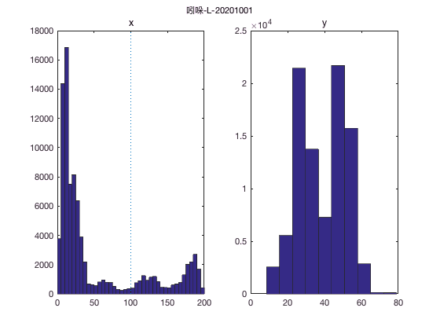

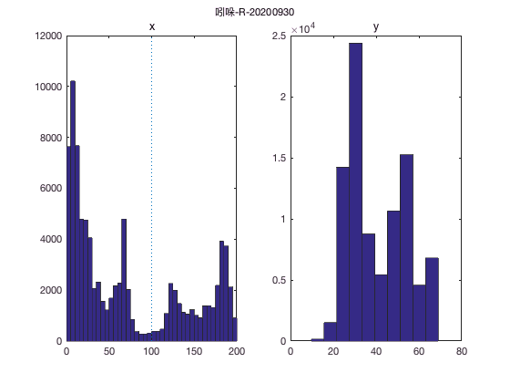

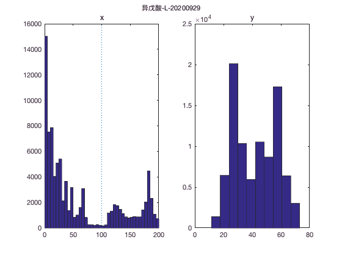

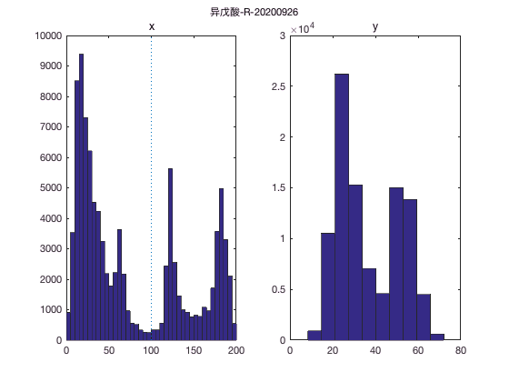

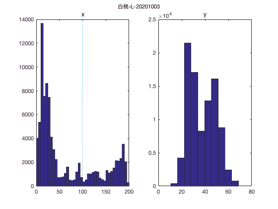

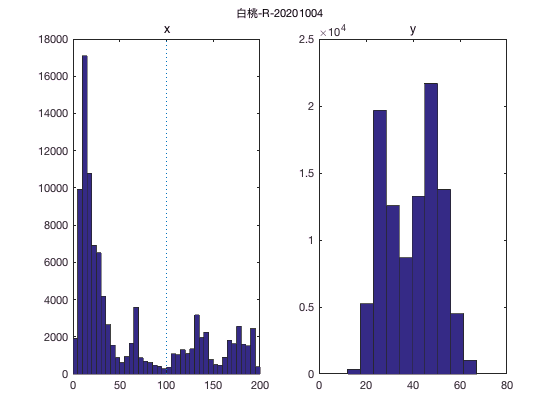

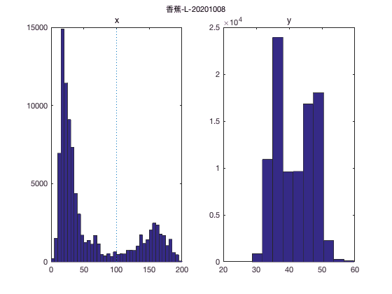

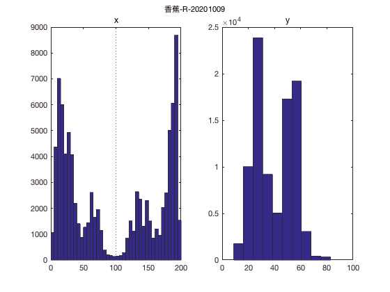

## 合并4个条件

tic;

interval=10;

% concatenate all the data

data=cell2mat(alldata');

expect=zeros(3,2);

% chisq test

disp('all days');

all days

for i=0:10:20

cutl=100-i;

cutr=100+i;

disp([cutl cutr])

[pvalue,st]=chit(data,cutl,cutr)

expect(i/10+1,:)=st.O;

end

100 100

pvalue = 0

st =

chi2stat: 1.0483e+05  
df: 1  
edges: [0 100 200]  
O: [513527 233660]  
E: [3.7359e+05 3.7359e+05]

90 110

pvalue = 0

st =

chi2stat: 1.0658e+05  
df: 1  
edges: [0 100 200]  
O: [506619 226995]  
E: [366807 366807]

80 120

pvalue = 0

st =

chi2stat: 1.1730e+05  
df: 1  
edges: [0 100 200]  
O: [499825 211060]  
E: [3.5544e+05 3.5544e+05]

figure;

subplot(1,2,1)

hist(data(:,2),interval/2:interval:200-interval/2);

line([100 100],get(gca,'Ylim'),'linestyle',':')

title('x')

% y方向的分布

subplot(1,2,2)

hist(data(:,3));

title('y')

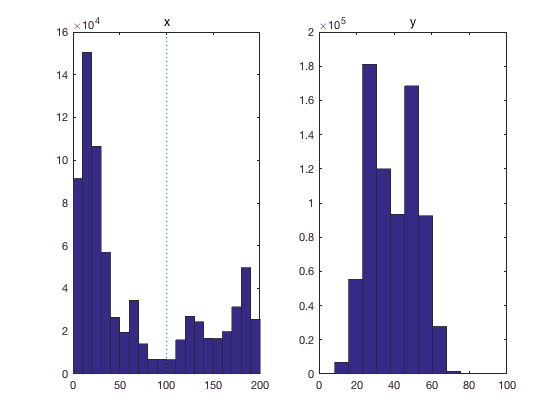

## 绘制热图

xx=data(:,2);

yy=data(:,3);

% sigma = 0.1;

gridSize = 100;

x=linspace(0,200,gridSize+1);

y=linspace(0,100,gridSize+1);

gridEval = zeros(length(x)-1,length(y)-1);

% 计算每个网格中点的频数

for cnt_x=1:length(x)-1

for cnt_y=1:length(y)-1

x_ind=xx>x(cnt_x) & xx<=x(cnt_x+1);

xy_ind=yy(x_ind)>y(cnt_y) & yy(x_ind)<=y(cnt_y+1);

gridEval(cnt_y, cnt_x)=length(yy(xy_ind));

end

end

% % 计算每个点处的高斯函数

% for i = 1:length(x)-1

% for j = 1:length(y)-1

% %calculate a Gaussian function on the grid with each point in the center and add them up

% gridEval(j,i) = gridEval(j,i) + sum(exp(-(((x(i)-xx).^2)./(2*sigma.^2) + ((y(j)-yy).^2)./(2*sigma.^2))));

% end

% end

% 绘制热图

figure;

surf((x(1:end-1)+ x(2:end))/2,(y(1:end-1)+y(2:end))/2,gridEval); view(2); shading interp;

% 增加z轴会变成三维的

% axis([0 200 0 100 0 100]);

axis([0 200 0 100])

h1 = gca; % 保存句柄，以便后面添加边框

set(gca, 'CLim', [0 400]);

% 添加标注

% title(['平滑散点图, \sigma = ' num2str(sigma) ', 网格数： ' num2str(gridSize) ' x' num2str(gridSize)],'Fontsize',14);

title(['网格数： ' num2str(gridSize) ' x' num2str(gridSize)]);

xlabel('x','Fontsize',14);

ylabel('y','Fontsize',14);

% 添加颜色条

colormap jet

colorbar;

ylabel('Intensity','Fontsize',14);

% 添加黑色的边框

axes(h1);

line(get(gca,'xlim'),repmat(min(get(gca,'ylim')),1,2),'color',[0 0 0],'linewidth',1);

line(get(gca,'xlim'),repmat(max(get(gca,'ylim')),1,2),'color',[0 0 0],'linewidth',2);

line(repmat(min(get(gca,'xlim')),1,2),get(gca,'ylim'),'color',[0 0 0],'linewidth',2);

line(repmat(max(get(gca,'xlim')),1,2),get(gca,'ylim'),'color',[0 0 0],'linewidth',1);

set(gcf,'color',[1 1 1],'paperpositionmode','auto');

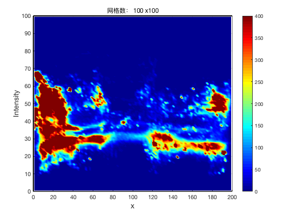

toc;

时间已过 37.914557 秒。

## 合并odor两个条件

tic;

interval=10;

for odor=2:2:length(conditions)

data=alldata{odor};

data(:,2)=200-data(:,2);

data=[alldata{odor-1};data];

% chisq test

disp(conditions{odor-1})

for i=0:10:20

cutl=100-i;

cutr=100+i;

disp([cutl cutr])

[pvalue,st]=chit(data,cutl,cutr,expect(i/10+1,:))

end

figure;

subplot(1,2,1)

hist(data(:,2),interval/2:interval:200-interval/2);

line([100 100],get(gca,'Ylim'),'linestyle',':')

title('x')

% y方向的分布

subplot(1,2,2)

hist(data(:,3));

title('y')

t=conditions{odor-1};

suptitle(t(1:end-9));

% 绘制热图

xx=data(:,2);

yy=data(:,3);

% sigma = 0.1;

gridSize = 100;

x=linspace(0,200,gridSize+1);

y=linspace(0,100,gridSize+1);

gridEval = zeros(length(x)-1,length(y)-1);

% 计算每个网格中点的频数

for cnt_x=1:length(x)-1

for cnt_y=1:length(y)-1

x_ind=xx>x(cnt_x) & xx<=x(cnt_x+1);

xy_ind=yy(x_ind)>y(cnt_y) & yy(x_ind)<=y(cnt_y+1);

gridEval(cnt_y, cnt_x)=length(yy(xy_ind));

end

end

% % 计算每个点处的高斯函数

% for i = 1:length(x)-1

% for j = 1:length(y)-1

% %calculate a Gaussian function on the grid with each point in the center and add them up

% gridEval(j,i) = gridEval(j,i) + sum(exp(-(((x(i)-xx).^2)./(2*sigma.^2) + ((y(j)-yy).^2)./(2*sigma.^2))));

% end

% end

% 绘制热图

figure;

surf((x(1:end-1)+ x(2:end))/2,(y(1:end-1)+y(2:end))/2,gridEval); view(2); shading interp;

% 增加z轴会变成三维的

% axis([0 200 0 100 0 100]);

axis([0 200 0 100])

h1 = gca; % 保存句柄，以便后面添加边框

set(gca, 'CLim', [0 400]);

% 添加标注

% title(['平滑散点图, \sigma = ' num2str(sigma) ', 网格数： ' num2str(gridSize) ' x' num2str(gridSize)],'Fontsize',14);

title([t(1:end-9) ' 网格数： ' num2str(gridSize) ' x' num2str(gridSize)]);

xlabel('x','Fontsize',14);

ylabel('y','Fontsize',14);

% 添加颜色条

colormap jet

colorbar;

ylabel('Intensity','Fontsize',14);

% 添加黑色的边框

axes(h1);

line(get(gca,'xlim'),repmat(min(get(gca,'ylim')),1,2),'color',[0 0 0],'linewidth',1);

line(get(gca,'xlim'),repmat(max(get(gca,'ylim')),1,2),'color',[0 0 0],'linewidth',2);

line(repmat(min(get(gca,'xlim')),1,2),get(gca,'ylim'),'color',[0 0 0],'linewidth',2);

line(repmat(max(get(gca,'xlim')),1,2),get(gca,'ylim'),'color',[0 0 0],'linewidth',1);

set(gcf,'color',[1 1 1],'paperpositionmode','auto');

end

吲哚-L-20201001

100 100

pvalue = 0

st =

chi2stat: 1.6239e+04  
df: 1  
edges: [0 100 200]  
O: [100361 82414]  
E: [1.2562e+05 5.7157e+04]

90 110

pvalue = 0

st =

chi2stat: 1.6420e+04  
df: 1  
edges: [0 100 200]  
O: [98910 80665]  
E: [1.2401e+05 5.5564e+04]

80 120

pvalue = 0

st =

chi2stat: 1.8544e+04  
df: 1  
edges: [0 100 200]  
O: [96825 77872]  
E: [1.2283e+05 5.1867e+04]

异戊酸-L-20200929

100 100

pvalue = 0

st =

chi2stat: 2.2164e+04  
df: 1  
edges: [0 100 200]  
O: [99698 88985]  
E: [1.2968e+05 5.9005e+04]

90 110

pvalue = 0

st =

chi2stat: 2.3047e+04  
df: 1  
edges: [0 100 200]  
O: [98570 88066]  
E: [1.2889e+05 5.7749e+04]

80 120

pvalue = 0

st =

chi2stat: 2.6146e+04  
df: 1  
edges: [0 100 200]  
O: [95119 84726]  
E: [1.2645e+05 5.3396e+04]

白桃-L-20201003

100 100

pvalue = 0

st =

chi2stat: 3.4830e+04  
df: 1  
edges: [0 100 200]  
O: [94669 98389]  
E: [1.3268e+05 6.0373e+04]

90 110

pvalue = 0

st =

chi2stat: 3.7656e+04  
df: 1  
edges: [0 100 200]  
O: [90551 96794]  
E: [1.2938e+05 5.7968e+04]

80 120

pvalue = 0

st =

chi2stat: 4.2901e+04  
df: 1  
edges: [0 100 200]  
O: [86498 93653]  
E: [1.2666e+05 5.3486e+04]

香蕉-L-20201008

100 100

pvalue = 0

st =

chi2stat: 4.2072e+03  
df: 1  
edges: [0 100 200]  
O: [112694 69977]  
E: [1.2555e+05 5.7125e+04]

90 110

pvalue = 0

st =

chi2stat: 4.3692e+03  
df: 1  
edges: [0 100 200]  
O: [111379 68679]  
E: [1.2434e+05 5.5714e+04]

80 120

pvalue = 0

st =

chi2stat: 5.7472e+03  
df: 1  
edges: [0 100 200]  
O: [109342 66850]  
E: [1.2388e+05 5.2311e+04]

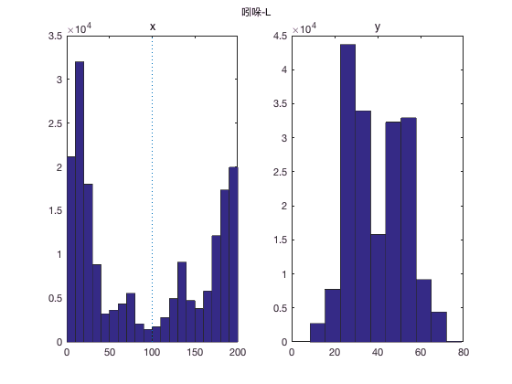

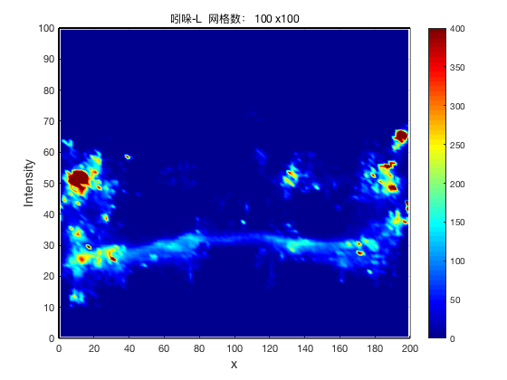

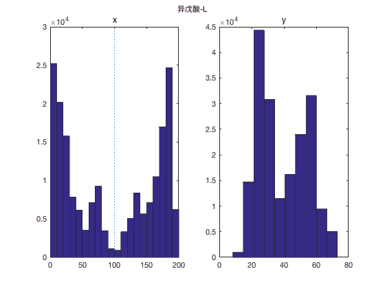

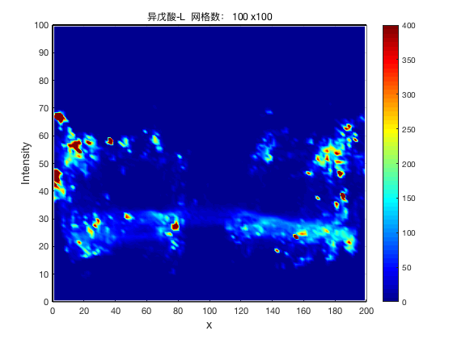

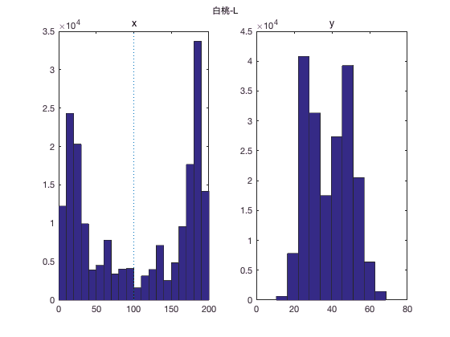

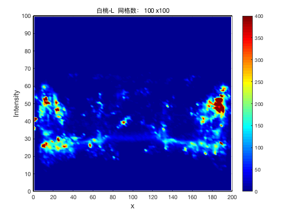

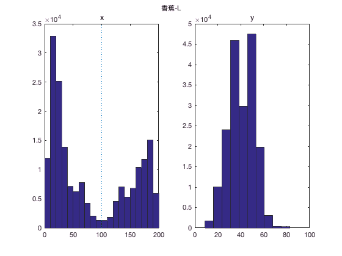

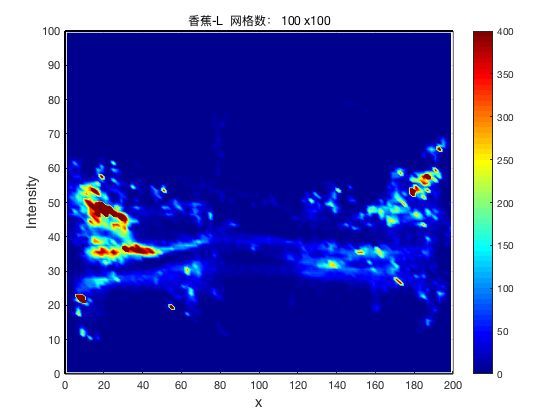

toc;

时间已过 49.716679 秒。

## 合并odor两个条件的（只取前面一段时间）

interval=10;

timeint=10;%minute

p1=1;

p2=timeint*60*1000/40;

% 1和3合并为1的方向

for odor=2:2:length(conditions)

data=alldata{odor};

data(:,2)=200-data(:,2);

data=[alldata{odor-1}(p1:p2,:);data(p1:p2,:)];

data=data(data(:,2)<=50|data(:,2)>=150,:);

% chisq test

for i=0

cutl=100-i;

cutr=100+i;

disp([cutl cutr])

[pvalue,st]=chit(data,cutl,cutr)

end

figure;

subplot(1,2,1)

hist(data(:,2),interval/2:interval:200-interval/2);

line([100 100],get(gca,'Ylim'),'linestyle',':')

title('x')

% y方向的分布

subplot(1,2,2)

hist(data(:,3));

title('y')

t=conditions{odor-1};

suptitle(t(1:end-9));

end

100 100

pvalue = 0

st =

chi2stat: 1.9553e+03  
df: 1  
edges: [0 100 200]  
O: [14054 7554]  
E: [10804 10804]

100 100

pvalue = 3.2995e-17

st =

chi2stat: 71.1567  
df: 1  
edges: [0 100 200]  
O: [8891 10052]  
E: [9.4715e+03 9.4715e+03]

100 100

pvalue = 3.5172e-35

st =

chi2stat: 153.1696  
df: 1  
edges: [0 100 200]  
O: [10574 12452]  
E: [11513 11513]

100 100

pvalue = 0

st =

chi2stat: 2.0962e+03  
df: 1  
edges: [0 100 200]  
O: [14024 7333]  
E: [1.0678e+04 1.0678e+04]

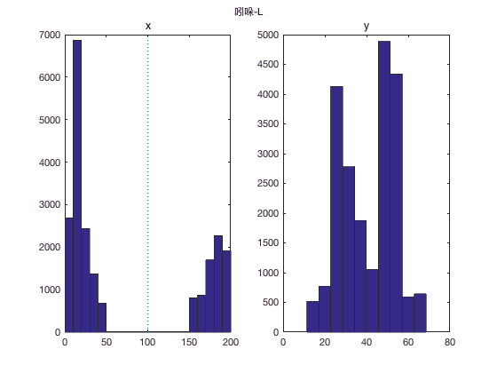

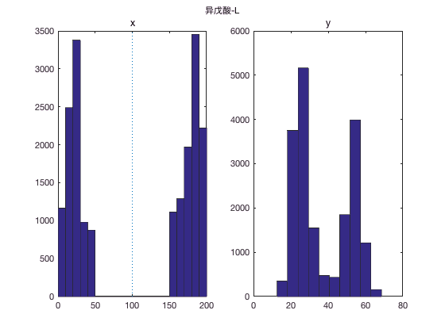

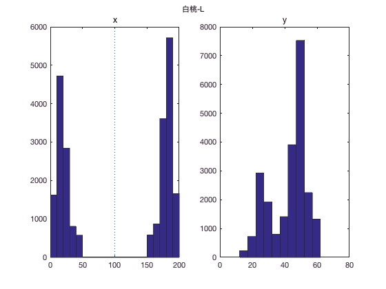

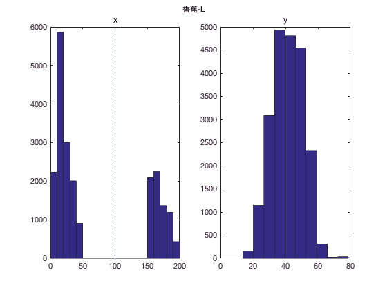

timeint=9.1;%minute

p=round(timeint*60*1000/40);

interval=5;

% plot each day

for f=1:length(files)

data=alldata{f};

l=length(data(:,2));

plots=ceil(l/p);

disp('===========================')

disp(conditions{f})

disp('===========================')

for j=0:10:50

timelab=zeros(1,l);

leftright=timelab;

cutl=100-j;

cutr=100+j;

leftright(data(:,2)<cutl)=1;

leftright(data(:,2)>cutl)=2;

for i=1:plots

timelab(p*(i-1)+1:min(p*i,l))=i;

end

timelab(leftright==0)=[];

leftright(leftright==0)=[];

[tbl,chi2,pvalue] = crosstab(timelab,leftright);

disp('-------------')

disp([num2str(cutl) '-' num2str(cutr)])

disp(tbl)

disp(chi2)

disp(pvalue)

disp('-------------')

% barplot

percenttbl=tbl./sum(tbl,2);

figure;

barh(percenttbl,'stack')

set(gca,'YDir','reverse')

title(conditions{f})

end

figure;

set(gcf,'position',[1280,720,ceil(plots/2)*400,2*300]);

% subplot each bin

for i=1:plots

subplot(2,ceil(plots/2),i)

hist(data(p*(i-1)+1:min(p*i,l),2),interval/2:interval:200-interval/2)

line([100 100],get(gca,'Ylim'),'linestyle',':')

% disp('-------------')

% disp([num2str(p*(i-1)+1) '-' num2str(min(p*i,l))])

%

% chisq test

for j=0%:10:20

cutl=100-j;

cutr=100+j;

% disp([cutl cutr])

[pvalue,st]=chit(data(p*(i-1)+1:min(p*i,l),:),cutl,cutr);

end

% disp('-------------')

title({[num2str(p*(i-1)+1) '-' num2str(min(p*i,l))];[num2str(cutl) '-' num2str(cutr) ' : ' num2str(st.O)]})

end

suptitle({conditions{f};''});

end

===========================

吲哚-L-20201001

===========================

-------------

100-100

9649 4001  
10587 3063  
10838 2812  
10277 3373  
10654 2996  
11242 2408  
6754 2398

656.0782

1.8531e-138

-------------

-------------

90-110

9567 4083  
10506 3144  
10558 3092  
10210 3440  
10592 3058  
11186 2464  
6707 2445

615.3586

1.1339e-129

-------------

-------------

80-120

9488 4162  
10434 3216  
10407 3243  
10120 3530  
10525 3125  
11137 2513  
6674 2478

615.2835

1.1770e-129

-------------

-------------

70-130

9328 4322  
10334 3316  
10036 3614  
9902 3748  
10303 3347  
11008 2642  
6591 2561

613.5724

2.7538e-129

-------------

-------------

60-140

8953 4697  
10109 3541  
9806 3844  
9600 4050  
10049 3601  
10773 2877  
6457 2695

678.8996

2.1973e-143

-------------

-------------

50-150

8670 4980  
9898 3752  
9604 4046  
9433 4217  
9853 3797  
10571 3079  
6355 2797

700.4968

4.7780e-148

-------------

===========================

吲哚-R-20200930

===========================

-------------

100-100

6951 6699  
8364 5286  
8927 4723  
11139 2511  
8004 5646  
10411 3239  
7567 2256

4.5330e+03

0

-------------

-------------

90-110

6819 6831  
8263 5387  
8837 4813  
11073 2577  
7903 5747  
10338 3312  
7526 2297

4.6310e+03

0

-------------

-------------

80-120

6676 6974  
8156 5494  
8752 4898  
10981 2669  
7801 5849  
10265 3385  
7479 2344

4.7073e+03

0

-------------

-------------

70-130

6373 7277  
7340 6310  
8464 5186  
10495 3155  
7189 6461  
10014 3636  
7355 2468

4.9926e+03

0

-------------

-------------

60-140

5523 8127  
5830 7820  
7287 6363  
9321 4329  
6477 7173  
9172 4478  
6540 3283

4.6432e+03

0

-------------

-------------

50-150

4439 9211  
5426 8224  
6580 7070  
8626 5024  
6109 7541  
8744 4906  
6376 3447

5.3047e+03

0

-------------

===========================

异戊酸-L-20200929

===========================

-------------

100-100

4928 8722  
10794 2856  
9432 4218  
10643 3007  
11625 2025  
9958 3692  
6481 1749

1.0416e+04

0

-------------

-------------

90-110

4849 8801  
10599 3051  
9388 4262  
10600 3050  
11606 2044  
9917 3733  
6445 1785

1.0345e+04

0

-------------

-------------

80-120

4759 8891  
10425 3225  
9341 4309  
10556 3094  
11587 2063  
9879 3771  
6409 1821

1.0344e+04

0

-------------

-------------

70-130

4391 9259  
10319 3331  
9241 4409  
10446 3204  
11549 2101  
9791 3859  
6141 2089

1.0959e+04

0

-------------

-------------

60-140

3315 10335  
9591 4059  
8639 5011  
9327 4323  
11462 2188  
8912 4738  
5935 2295

1.2205e+04

0

-------------

-------------

50-150

2976 10674  
9470 4180  
8207 5443  
8863 4787  
11407 2243  
8614 5036  
5796 2434

1.2607e+04

0

-------------

===========================

异戊酸-R-20200926

===========================

-------------

100-100

6439 7211  
8125 5525  
7783 5867  
8357 5293  
9348 4302  
9788 3862  
10320 3330  
2556 447

3.9578e+03

0

-------------

-------------

90-110

6349 7301  
8061 5589  
7671 5979  
8282 5368  
9324 4326  
9708 3942  
10265 3385  
2548 455

4.0283e+03

0

-------------

-------------

80-120

6256 7394  
8007 5643  
7475 6175  
8194 5456  
9281 4369  
9411 4239  
10201 3449  
2540 463

3.9900e+03

0

-------------

-------------

70-130

6064 7586  
7902 5748  
7272 6378  
7885 5765  
9215 4435  
8953 4697  
10029 3621  
2524 479

3.9483e+03

0

-------------

-------------

60-140

5343 8307  
6692 6958  
5614 8036  
6934 6716  
8917 4733  
8409 5241  
9624 4026  
2507 496

5.8762e+03

0

-------------

-------------

50-150

4572 9078  
6370 7280  
4957 8693  
6561 7089  
8760 4890  
7950 5700  
8378 5272  
2494 509

6.0557e+03

0

-------------

===========================

白桃-L-20201003

===========================

-------------

100-100

7534 6116  
8706 4944  
8924 4726  
10106 3544  
11860 1790  
10303 3347  
9022 1381

5.3958e+03

0

-------------

-------------

90-110

7437 6213  
7972 5678  
7670 5980  
9962 3688  
11547 2103  
10216 3434  
8990 1413

6.4671e+03

0

-------------

-------------

80-120

7352 6298  
7818 5832  
7262 6388  
9578 4072  
11238 2412  
9860 3790  
8969 1434

6.2664e+03

0

-------------

-------------

70-130

7224 6426  
7615 6035  
7144 6506  
9444 4206  
11175 2475  
9591 4059  
8912 1491

6.3240e+03

0

-------------

-------------

60-140

6879 6771  
6773 6877  
6866 6784  
9182 4468  
10867 2783  
9253 4397  
8584 1819

6.4967e+03

0

-------------

-------------

50-150

6485 7165  
6561 7089  
6681 6969  
9076 4574  
10720 2930  
8949 4701  
8426 1977

6.6676e+03

0

-------------

===========================

白桃-R-20201004

===========================

-------------

100-100

8286 5364  
8898 4752  
9537 4113  
10704 2946  
9567 4083  
10784 2866  
10297 3353  
4468 737

2.4192e+03

0

-------------

-------------

90-110

8208 5442  
8827 4823  
9441 4209  
10661 2989  
9459 4191  
10706 2944  
10107 3543  
4437 768

2.3759e+03

0

-------------

-------------

80-120

8128 5522  
8765 4885  
9385 4265  
10629 3021  
9002 4648  
10527 3123  
9914 3736  
4404 801

2.3587e+03

0

-------------

-------------

70-130

8001 5649  
8682 4968  
9286 4364  
10539 3111  
8426 5224  
10345 3305  
9569 4081  
4342 863

2.4359e+03

0

-------------

-------------

60-140

7697 5953  
8421 5229  
8930 4720  
9474 4176  
7958 5692  
9516 4134  
8438 5212  
3515 1690

983.7610

3.8841e-208

-------------

-------------

50-150

7520 6130  
8253 5397  
8753 4897  
9294 4356  
7784 5866  
9321 4329  
8087 5563  
3389 1816

967.8709

1.0523e-204

-------------

===========================

香蕉-L-20201008

===========================

-------------

100-100

9325 4325  
9722 3928  
9614 4036  
10118 3532  
10827 2823  
10786 2864  
9145 1416

1.6036e+03

0

-------------

-------------

90-110

8977 4673  
9630 4020  
9517 4133  
9974 3676  
10635 3015  
10701 2949  
9109 1452

1.7761e+03

0

-------------

-------------

80-120

8848 4802  
9557 4093  
9322 4328  
9853 3797  
10532 3118  
10638 3012  
8879 1682

1.6330e+03

0

-------------

-------------

70-130

8749 4901  
9145 4505  
8844 4806  
9681 3969  
10252 3398  
10544 3106  
8775 1786

1.8055e+03

0

-------------

-------------

60-140

8608 5042  
8984 4666  
7985 5665  
9179 4471  
9746 3904  
10084 3566  
8595 1966

1.9172e+03

0

-------------

-------------

50-150

8301 5349  
8805 4845  
7450 6200  
8841 4809  
9429 4221  
9860 3790  
7875 2686

1.5978e+03

0

-------------

===========================

香蕉-R-20201009

===========================

-------------

100-100

6256 7394  
6634 7016  
9161 4489  
6963 6687  
8365 5285  
7782 5868  
1892 6418

4.9797e+03

0

-------------

-------------

90-110

6182 7468  
6551 7099  
9116 4534  
6917 6733  
8340 5310  
7743 5907  
1890 6420

4.9608e+03

0

-------------

-------------

80-120

5965 7685  
6427 7223  
9045 4605  
6835 6815  
8301 5349  
7688 5962  
1888 6422

4.9922e+03

0

-------------

-------------

70-130

5531 8119  
5493 8157  
8339 5311  
6282 7368  
8055 5595  
7458 6192  
1882 6428

4.6370e+03

0

-------------

-------------

60-140

4501 9149  
4218 9432  
7692 5958  
5630 8020  
7842 5808  
7073 6577  
1811 6499

5.5064e+03

0

-------------

-------------

50-150

4067 9583  
3593 10057  
6833 6817  
5249 8401  
7687 5963  
6859 6791  
1772 6538

5.5656e+03

0

-------------